# Campaign Financing and its Relation to Election Results

Vincent Lien, Tharyn McConnell, Philip Huynh

2024-05-07

## Introduction

Over the past decade there has been a continual increase in total spending and focus on political elections. In 2016 alone presidential candidates received and spend approximately $1.5 billion on the election. Congressional candidates also spent and received approximately $1.6 billion dollars in total. With this increased amount of spending, who is benefitting the most? In other words we would like to determine if there is a direct correlation between having more funding than an opponent and liklihood of winning an election. We would also like to see what geographic regions tend to receive the greatest amount of campaign contributions. Lastly, we would like to examine the relationship of political party and campaign finances.

In 1971 the Federal Election Campaign Act was passed by congress which introduced an act that regulated raising and spending of money in U.S. federal elections. This act and subsequent amendments imposed restrictions on the amount a candidate can receive and restricted the amount an entity could donate. This also mandated the disclosure of such contributions. Most of campaign contributions from businesses or individuals on the large scale are made through political action committees (PACs). As the direct contribution to a campaign candidate is illegal for firms, firms make use of PACs in order to contribute and sway federal elections.

This data contains information for various election candidates and their campaign finances. Recently, especially with news articles revolving around former president Trump, campaign finances has become a hot topic. In this we would like to explore the relationship between election candidates, their campaign finances, and the election results. This data is available on Kaggle datasets. The creator of the dataset stated that campaign finance information came directly from FEC.gov and the election results, and vote totals were taken from CNN’s election results page. The individuals in this dataset are election candidates for the house of representatives accross the nation for the time period of 1/1/2015 to 10/19/2016.

https://www.kaggle.com/datasets/danerbland/electionfinance?resource=download

## Code Book

| Header | Description | Class | Data Type |
| --- | --- | --- | --- |
| `can_id` | Candidate Id | Categorical | H=House, S=Senate, P=Presidential, e.g., “H2GA12121” |
| `can_name` | Candidate Name | Categorical | Full names, e.g., “ALLEN, RICHARD W” |
| `can_off` | Candidate Office | Categorical | “H” (House), “S” (Senate), “P” (President) |
| `can_off_sta` | Candidate Office State | Categorical | US State Abbreviations, e.g., “GA” |
| `can_off_dis` | Candidate Office District | Categorical | District numbers, e.g., 12 |
| `can_par_aff` | Candidate Party Affiliation | Categorical | “DEM”, “REP”, etc. |
| `can_inc_cha_ope_sea` | Candidate Incumbent Challenger Open Seat | Categorical | “INCUMBENT”, “CHALLENGER”, “OPEN” |
| `can_cit` | Candidate City | Categorical | City names, e.g., “AUGUSTA” |
| `can_sta` | Candidate State | Categorical | US State Abbreviations, e.g., “GA” |
| `can_zip` | Candidate Zip | Categorical | ZIP codes, e.g., 30904 |
| `ind_ite_con` | Individual Itemized Contribution | Numerical | Dollar amount, e.g., $500,000.00 |
| `ind_uni_con` | Individual Unitemized Contribution | Numerical | Dollar amount |
| `ind_con` | Individual Contribution | Numerical | Dollar amount |
| `par_com_con` | Party Committee Contribution | Numerical | Dollar amount |
| `oth_com_con` | Other Committee Contribution | Numerical | Dollar amount |
| `can_con` | Candidate Contribution | Numerical | Dollar amount |
| `tot_con` | Total Contribution | Numerical | Dollar amount |
| `tra_fro_oth_aut_com` | Transfer from other Authorized Committee | Numerical | Dollar amount |
| `can_loa` | Candidate Loan | Numerical | Dollar amount |
| `oth_loa` | Other Loan | Numerical | Dollar amount |
| `tot_loa` | Total Loan | Numerical | Dollar amount |
| `off_to_ope_exp` | Offsets to Operating Expenditure | Numerical | Dollar amount |
| `off_to_fun` | Offsets to Fundraising | Numerical | Dollar amount |
| `off_to_leg_acc` | Offsets to Legal Accounting | Numerical | Dollar amount |
| `oth_rec` | Other Receipts | Numerical | Dollar amount |
| `tot_rec` | Total Receipts | Numerical | Dollar amount |
| `ope_exp` | Operating Expenditure | Numerical | Dollar amount |
| `exe_leg_acc_dis` | Exempt Legal Accounting Disbursement | Numerical | Dollar amount |
| `fun_dis` | Fundraising Disbursement | Numerical | Dollar amount |
| `tra_to_oth_aut_com` | Transfer to Other Authorized Committee | Numerical | Dollar amount |
| `can_loa_rep` | Candidate Loan Repayment | Numerical | Dollar amount |
| `oth_loa_rep` | Other Loan Repayment | Numerical | Dollar amount |
| `tot_loa_rep` | Total Loan Repayment | Numerical | Dollar amount |
| `ind_ref` | Individual Refund | Numerical | Dollar amount |
| `par_com_ref` | Party Committee Refund | Numerical | Dollar amount |
| `oth_com_ref` | Other Committee Refund | Numerical | Dollar amount |
| `tot_con_ref` | Total Contribution Refund | Numerical | Dollar amount |
| `oth_dis` | Other Disbursement | Numerical | Dollar amount |
| `tot_dis` | Total Disbursement | Numerical | Dollar amount |
| `cas_on_han_beg_of_per` | Cash on Hand Beginning of Period | Numerical | Dollar amount |
| `cas_on_han_clo_of_per` | Cash on Hand Close of Period | Numerical | Dollar amount |
| `net_con` | Net Contribution | Numerical | Dollar amount |
| `net_ope_exp` | Net Operating Expenditure | Numerical | Dollar amount |
| `deb_owe_by_com` | Debt Owed by Committee | Numerical | Dollar amount |
| `deb_owe_to_com` | Debt Owed to Committee | Numerical | Dollar amount |
| `cov_sta_dat` | Coverage Start Date | Categorical | Date, e.g., “1/1/2015” |
| `cov_end_dat` | Coverage End Date | Categorical | Date, e.g., “1/1/2015” |
| `winner` | Election Winner Indicator | Categorical | “Y” if winner |
| `votes` | Number of Votes Received | Categorical | Number, e.g., 158708 |

## Glimpse of Data

```
## Rows: 1,814
## Columns: 52
## $ can_id                <chr> "H2GA12121", "H6PA02171", "H6FL04105", "H4MT0104…
## $ can_nam               <chr> "ALLEN, RICHARD W", "EVANS, DWIGHT", "RUTHERFORD…
## $ can_off               <chr> "H", "H", "H", "H", "H", "H", "H", "H", "H", "H"…
## $ can_off_sta           <chr> "GA", "PA", "FL", "MT", "CA", "NC", "WI", "MA", …
## $ can_off_dis           <int> 12, 2, 4, 0, 13, 4, 2, 8, 2, 4, 5, 11, 1, 1, 12,…
## $ can_par_aff           <chr> "REP", "DEM", "REP", "REP", "DEM", "DEM", "DEM",…
## $ can_inc_cha_ope_sea   <chr> "INCUMBENT", "CHALLENGER", "OPEN", "INCUMBENT", …
## $ can_str1              <chr> "2237 PICKENS RD", "PO BOX 6578", "3817 VICKERS …
## $ can_str2              <chr> "", "", "", "", "", "", "", "", "", "", "", "", …
## $ can_cit               <chr> "AUGUSTA", "PHILADELPHIA", "JACKSONVILLE", "WHIT…
## $ can_sta               <chr> "GA", "PA", "FL", "MT", "CA", "NC", "WI", "MA", …
## $ can_zip               <int> 30904, 19138, 32224, 599373010, 94612, 27602, 53…
## $ ind_ite_con           <chr> "$554,305.00 ", "$1,042,280.38 ", "$529,030.38 "…
```

[output cut: 39 more lines]

## Data Analysis Plan

#### Outcome Variable

Our primary numerical outcome variable will be **votes** (`votes`). This is the dependent variable of the study, and serves as a measure of success of each candidate in their respective elections.

#### Predictor Variables

- **Total Contributions** ($) (`total_con`): Measures amount of all monetary contributions to a candidate. This evaluates overall financial support.
- **Other Committee Contribution** ($) (`oth_com_con`): Measures mostly contributions from PAC’s and other candidates.
- **Political Party** (`can_par_aff`): Indicates party affiliation. Used to explore how financial results can vary across different parties.
- **Candidate Office State** (`can_off_state`): Indicates state associated with the office for which the candidate is running. Used for understanding elections at a state level.

#### Challenges

The biggest current challenge we have with this data set is that all of the currency values are currently strings, meaning we need to convert them to numeric types. Another challenge will be dealing with some very extreme outliers, which can heavily influence the results of stats models. Some candidates received a much higher amount than the majority of candidates skewing the data. Another challenge will be in figuring out which candidates ran against each other in order to have a meaningful comparison between campaign candidate funds and election results.

#### Initial Data Analysis

For all candidates in this data set, the overall median total contributions received is $116,492.6, the mean is $1,395,240, the minimum total contributions received was $2, and the maximum received was $361,329,562. The incredibly large range will explain the large difference in median contributions and mean contributions received.

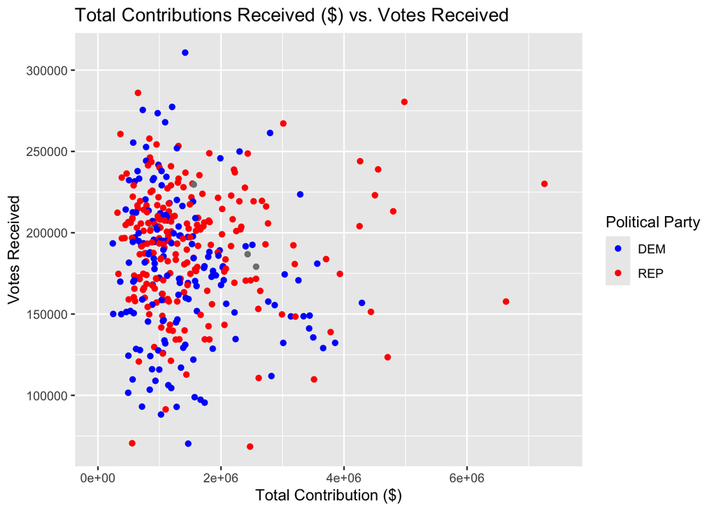

This visualization of two key variables, votes received and total contribution, along with the colorization of the two major parties, provides us with an initial glance into the spread and relationship of financial resources in a campaign and its coinciding success in elections. Using this, we can visually observe patterns and anomalies between these two variables.

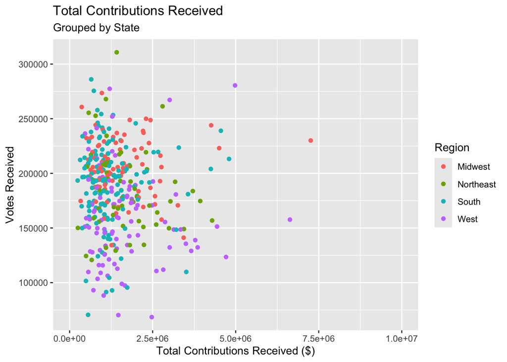

This visualization shows the amount of total contributions a candidate has received versus the amount of votes they received and color coded by geographic region. This provides us with an initial glance into which geographic regions tend to receive more political contributions compared to other regions. This was created by getting rid of some of the largest outliers (28 candidates excluded). The challenge with this will be dealing with outliers in order to extrapolate any meaningful trends. It might be interesting to explore if there is a correlation with higher spending in a region and whether the candidate won their election.

```
##   can_par_aff   n
## 1         REP 882
## 2         DEM 714
## 3         IND  85
## 4         LIB  33
## 5         GRE  16
```

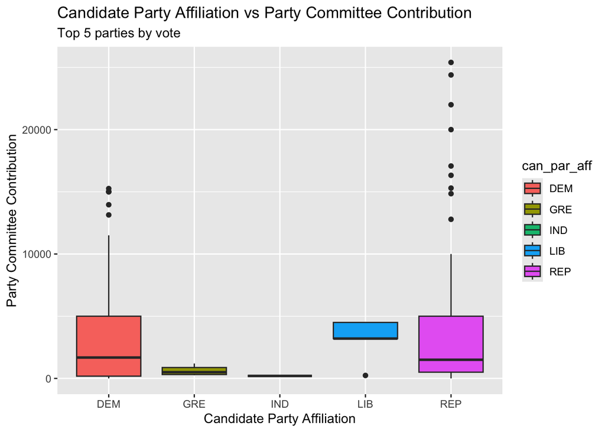

This visualization shows the amount of Party Committee contributions a candidate received in relation to the candidate’s party affiliation. This provides us with an initial glance into which political parties tend to receive more party committee funds contributions compared to other parties. This was created by excluding the 20 other relatively minor political parties. The challenge with this will be dealing with outliers in order to extrapolate any meaningful trends. It might be interesting to explore if there is a correlation with different party spending and how the party in question fair against other competitors.

## Bibliography

1. “Money in Politics 101: What You Need to Know about Campaign Finance after Citizens United.” Brennan Center for Justice, 28 Sept. 2012, www.brennancenter.org/our-work/research-reports/money-politics-101-what-you-need-know-about-campaign-finance-after.
2. “How Does Campaign Funding Work?” Caltech Science Exchange, scienceexchange.caltech.edu/topics/voting-elections/campaign-funding-finance-explained. Accessed 5 May 2024.
3. Jones, Clifford A. “Federal Election Campaign Act.” Encyclopædia Britannica, Encyclopædia Britannica, inc., www.britannica.com/topic/Federal-Election-Campaign-Act. Accessed 5 May 2024.
4. “Metadata Description.” Metadata for Candidate Summary, Federal Election Commission , 17 Jan. 2017, web.archive.org/web/20170118212350/www.fec.gov/finance/disclosure/metadata/metadataforcandidatesummary.shtml.